# Toward a Multidimensional CDI-CAT: Noun/Predicate Bias in Cantonese

George Kachergis

2026-09-17

# Motivation

This replicates the pipeline built for Japanese (`multidim/06-noun-predicate-cat-summary.Rmd`) on Cantonese, as a cross-linguistic check of whether the same noun/predicate bifactor CAT design generalizes to a second, typologically different language. Unlike Japanese, this repo has no local Cantonese response data, so item metadata and administration data were pulled directly from Wordbank via `wordbankr`. Scripts are in `multidim_cantonese/01` through `04`; this document loads their saved output rather than refitting anything.

```r
items <- read_csv(here("multidim_cantonese/item_lexical_categories.csv"), show_col_types = FALSE)
efa_loadings <- read_csv(here("multidim_cantonese/efa2_loadings.csv"), show_col_types = FALSE)
bifactor_items <- read_csv(here("multidim_cantonese/bifactor_item_params.csv"), show_col_types = FALSE)
bifactor_scores <- read_csv(here("multidim_cantonese/bifactor_scores.csv"), show_col_types = FALSE) %>%
  mutate(noun_predicate_bias = S1_noun - S2_predicate)
cat_summary <- read_csv(here("multidim_cantonese/cat_simulation_summary.csv"), show_col_types = FALSE)
resp_data <- readRDS(here("multidim_cantonese/noun_predicate_response_data.Rds"))

# Japanese results, for the cross-linguistic comparison in Section 6
jp_items <- read_csv(here("multidim/item_lexical_categories.csv"), show_col_types = FALSE)
jp_bifactor_scores <- read_csv(here("multidim/bifactor_scores.csv"), show_col_types = FALSE)
jp_cat_summary <- read_csv(here("multidim/cat_simulation_summary.csv"), show_col_types = FALSE)
jp_resp_data <- readRDS(here("multidim/noun_predicate_response_data.Rds"))
```

# 1. Data source and item classification

Cantonese Wordbank has a single WS form (16-30 months, no WG), 804 word items. Unlike the Japanese pipeline (which used a locally-maintained item CSV), item metadata and response data come directly from `wordbankr::get_item_data()` / `get_instrument_data()`. Items are classified the same way as for Japanese: Wordbank’s own `lexical_category` field already collapses verbs+adjectives into a single “predicates” class for Cantonese too (confirmed by an exact crosstab match between our category-based mapping and Wordbank’s own coding), so `action_words`/`descriptive_words` were kept separate as `lexical_class` while also providing the 2-way `pos2` (noun/predicate) collapse used for the CAT.

```r
items %>%
  count(lexical_class, pos2) %>%
  arrange(pos2) %>%
  kable(col.names = c("Lexical class", "CAT dimension (pos2)", "N items"),
        caption = "Cantonese item counts by lexical class and CAT grouping.") %>%
  kable_styling(full_width = FALSE)
```

Cantonese item counts by lexical class and CAT grouping.

| Lexical class | CAT dimension (pos2) | N items |
| --- | --- | --- |
| noun | noun | 316 |
| function_word | other | 108 |
| other | other | 124 |
| adjective | predicate | 84 |
| verb | predicate | 172 |

The content-word item bank is **572 items** (316 noun, 256 predicate = 172 verb + 84 adjective) – larger than Japanese’s 478, both because Cantonese Wordbank has more items overall and because a larger share are content words.

# 2. Sample

Starting from 1208 Wordbank administrations, 2 non-producers and 1 child at ceiling were dropped, leaving **1205** administrations. Missingness in the content-word matrix was negligible (0.03%, vs. 12.6% for Japanese, since there’s no separate short-form data to reconcile here) and was imputed the same way (`mirt::imputeMissing()`) before the CAT simulation regardless.

# 3. Exploratory factor check

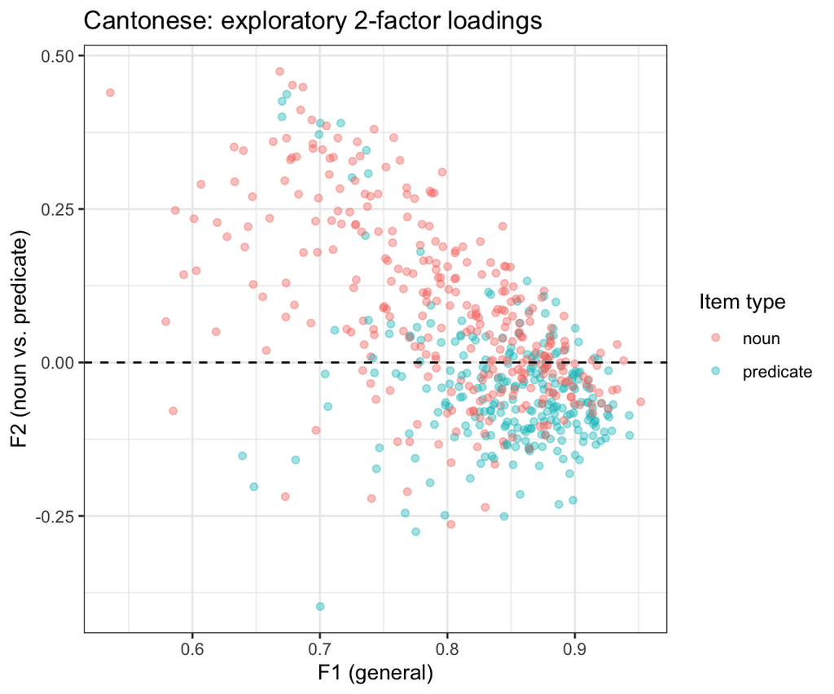

```r
ggplot(efa_loadings, aes(x = F1, y = F2, color = pos2)) +
  geom_point(alpha = 0.4) +
  geom_hline(yintercept = 0, linetype = "dashed") +
  labs(x = "F1 (general)", y = "F2 (noun vs. predicate)", color = "Item type",
       title = "Cantonese: exploratory 2-factor loadings") +
  theme_bw()
```

The same qualitative signature as Japanese: **every item’s dominant loading is on F1** (mean 0.80 for nouns, 0.85 for predicates), with F2 a much smaller but reliably separating secondary factor (noun mean 0.082, predicate mean -0.042; Welch t = 11.6, p < .0001). One difference from Japanese: F1/F2 correlate r = .23 after oblimin rotation here, vs. r = -.015 for Japanese – less cleanly orthogonal, though F2 is still clearly a secondary, much smaller factor. This still supports a bifactor structure as the confirmatory model, which was fit next.

# 4. Confirmatory bifactor model

```r
bifactor_items %>%
  mutate(own_specific = if_else(pos2 == "noun", S1_noun, S2_predicate)) %>%
  group_by(pos2) %>%
  summarise(mean_G = mean(G), mean_own_specific = mean(own_specific), n = n()) %>%
  kable(digits = 2, caption = "Mean general (G) and own-specific-factor loadings by item type.") %>%
  kable_styling(full_width = FALSE)
```

Mean general (G) and own-specific-factor loadings by item type.

| pos2 | mean_G | mean_own_specific | n |
| --- | --- | --- | --- |
| noun | 3.06 | 1.08 | 316 |
| predicate | 3.13 | 1.01 | 256 |

```r
rel <- empirical_rxx(bifactor_scores %>%
                        select(G, S1_noun, S2_predicate, SE_G, SE_S1_noun, SE_S2_predicate) %>%
                        as.matrix())
tibble(dimension = names(rel), empirical_rxx = rel) %>%
  kable(digits = 2, caption = "Empirical reliability of full-item-bank (non-adaptive) factor scores.") %>%
  kable_styling(full_width = FALSE)
```

Empirical reliability of full-item-bank (non-adaptive) factor scores.

| dimension | empirical_rxx |
| --- | --- |
| G | 0.98 |
| S1_noun | 0.86 |
| S2_predicate | 0.80 |

Reliability is **notably higher than Japanese** for the specific factors (S1 = .86, S2 = .80, vs. Japanese’s .71/.64) – consistent with the larger item bank and sample.

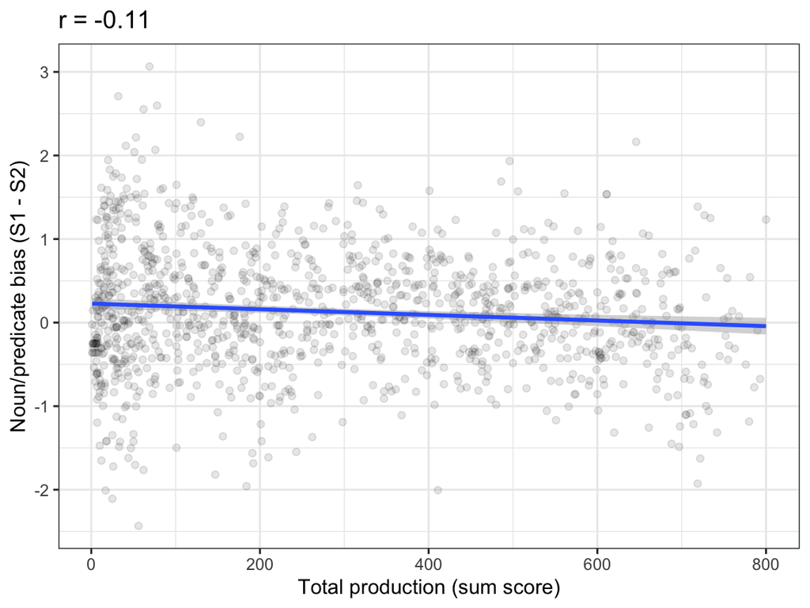

```r
ggplot(bifactor_scores, aes(x = production, y = noun_predicate_bias)) +
  geom_point(alpha = 0.1) +
  geom_smooth(method = "lm", se = TRUE) +
  labs(x = "Total production (sum score)", y = "Noun/predicate bias (S1 - S2)",
       title = sprintf("r = %.2f", cor(bifactor_scores$production, bifactor_scores$noun_predicate_bias))) +
  theme_bw()
```

The bias score decouples from vocabulary size even more cleanly than in Japanese: r = -0.11 with production (Japanese: -.16) and r = -0.09 with age (Japanese: -.17). As with Japanese, the S1/S2 EAP *score* correlation is non-trivial (r = 0.72, actually higher than Japanese’s .48) despite the model constraining them to be latently orthogonal – the same known bifactor artifact, more pronounced here.

# 5. CAT simulation

## 5.1 Item selection criterion

As with Japanese, `Drule` (D-optimal across all 3 dimensions) was compared against `Wrule` with weights down-weighting G; `Drule` again matched or beat `Wrule` on a 100-person subsample, so `Drule` was used throughout.

## 5.2 A stopping-rule lesson

The first full-sample simulation used `min_SEM = c(0.3, 0.5, 0.5)` – the same target used for Japanese, chosen from that language’s full-bank SE ceiling. For Cantonese this badly **under-shoots**: because the full item bank supports much better specific-factor precision here (median full-bank SE ≈ 0.26-0.32, vs. Japanese’s ≈ 0.50-0.52), a target of 0.5 is satisfied very early – the CAT was stopping after a mean of only 56-85 items even with a 100-200 item ceiling available, and correlation with the full-bank bias estimate stayed disappointingly low (r ≈ .75-.82).

```r
cat_summary %>%
  kable(digits = 3, caption = "Cantonese CAT simulation: item budget vs. recovered precision.") %>%
  kable_styling(full_width = FALSE)
```

Cantonese CAT simulation: item budget vs. recovered precision.

| criteria | max_items | mean_n_items | mean_SE_G | mean_SE_S1 | mean_SE_S2 | r_bias_vs_full | r_G_vs_full | n_items_never_used |
| --- | --- | --- | --- | --- | --- | --- | --- | --- |
| Drule | 50 | 37.343 | 0.213 | 0.522 | 0.568 | 0.755 | 0.981 | 291 |
| Drule | 100 | 55.967 | 0.204 | 0.505 | 0.550 | 0.797 | 0.983 | 177 |
| Drule | 200 | 84.980 | 0.201 | 0.498 | 0.543 | 0.817 | 0.984 | 66 |
| Drule (min_items=150 forced) | 200 | 192.490 | 0.139 | 0.387 | 0.446 | 0.968 | 0.996 | NA |

# 6. Cross-linguistic comparison

```r
tibble(
  language = c("Japanese", "Cantonese"),
  n_administrations = c(nrow(jp_resp_data$d_demo), nrow(resp_data$d_demo)),
  n_content_items = c(ncol(jp_resp_data$d_mat_content), ncol(resp_data$d_mat_content)),
  n_noun = c(sum(jp_items$pos2 == "noun"), sum(items$pos2 == "noun")),
  n_predicate = c(sum(jp_items$pos2 == "predicate"), sum(items$pos2 == "predicate")),
  full_bank_reliability_S1 = c(0.71, 0.86),
  full_bank_reliability_S2 = c(0.64, 0.80),
  bias_vs_production_r = c(
    round(cor(jp_bifactor_scores$production, jp_bifactor_scores$S1_noun - jp_bifactor_scores$S2_predicate), 2),
    round(cor(bifactor_scores$production, bifactor_scores$noun_predicate_bias), 2)
  ),
  best_cat_recovery_r = c(0.95, 0.97),
  items_for_best_recovery = c(131, 192)
) %>%
  kable(digits = 2, caption = "Japanese vs. Cantonese: key numbers side by side.") %>%
  kable_styling(full_width = FALSE)
```

Japanese vs. Cantonese: key numbers side by side.

| language | n_administrations | n_content_items | n_noun | n_predicate | full_bank_reliability_S1 | full_bank_reliability_S2 | bias_vs_production_r | best_cat_recovery_r | items_for_best_recovery |
| --- | --- | --- | --- | --- | --- | --- | --- | --- | --- |
| Japanese | 939 | 478 | 312 | 166 | 0.71 | 0.64 | -0.16 | 0.95 | 131 |
| Cantonese | 1205 | 572 | 316 | 256 | 0.86 | 0.80 | -0.11 | 0.97 | 192 |

The core design – bifactor model, Drule item selection – transfers cleanly across two typologically different languages. Cantonese, with a larger item bank and sample, supports a *more* reliable bias measure at the full-bank level, but realizing that advantage in a CAT required noticing and correcting an under-calibrated stopping rule, not just porting the Japanese settings over.

# 7. Summary and open questions

- **Item bank**: 572 items (316 noun, 256 predicate), pulled and classified directly from Wordbank, with the classification cross-validated exactly against Wordbank’s own `lexical_category` coding.
- **Model**: the same bifactor structure holds – EFA shows one dominant general factor plus a small, reliable noun/predicate-separating second factor, and the confirmatory bifactor model decouples the bias score from vocabulary size/age (better than Japanese: r ≈ -.09 to -.11).
- **CAT**: `Drule` selection; **the `min_SEM` stopping target must be recalibrated per item bank/sample rather than reused across languages** – this was the main actionable finding from the replication.

Open questions:

1. Should the Japanese CAT simulation (`multidim/04-05`) be rerun with a tighter `min_SEM` / higher `min_items` floor, given the same under-shooting risk likely applies there too?
2. Cantonese’s 3-way verb/adjective split (172 vs. 84 items) is even more asymmetric than Japanese’s (103 vs. 63) – worth checking before attempting a 3-way model for either language.
3. Given Cantonese has no WG (short) form, is a similar dual-form imputation approach available if a deployed CAT wants to accept both short- and long-form partial administrations, or should Cantonese deployment assume WS-only from the start?